# Lab 2a: MI Fundamentals

Missing Data in R

Kyle M. Lang

Updated: 2023-01-29

In these lab exercises, you are going to start working with multiple imputation (MI). Specifically, you will do some simple MI-based analyses using he **mice** package.

# 1 Single Imputation

## 1.1

**Load the mice package.**

The **mice** package contains several datasets. Once the package is loaded, you can access these datasets in your workspace. In this lab, we will work with the *nhanes* dataset ([Schafer, 1997](https://www.routledge.com/Analysis-of-Incomplete-Multivariate-Data/Schafer/p/book/9780412040610), Table 6.14).

The *nhanes* dataset is a small data set with non-monotone missing values. These data comprise 25 observations of four variables: *age group*, *body mass index*, *hypertension*, and *cholesterol*.

Unless otherwise specified, all subsequent questions refer to the *nhanes* dataset.

## 1.2

**Use the `mice()` function to impute the missing data using stochastic regression imputation.**

Set the random number seed by specifying a value for the `seed` argument.

## 1.3

**Use the `mice::densityplot()` function to check the imputed values.**

## 1.4

**Use the mice::complete() function to create a completed dataset.**

## 1.5

**Use the imputed data to regress `bmi` onto `age`.**

## 1.6

**Check the affect of the random number seed.**

Rerun the imputation that you did above two times

1. Once using the same value for the random number seed
2. Once using a different value for the random number seed

Confirm that you get the same results in the first case and different results in the second case.

# 2 Multiple Imputation

## 2.1

**Check the documentation for the `mice()` function.**

## 2.2

**Use the `mice()` function to multiply impute the *nhanes* data using all default options.**

The object returned by `mice()` has the class *mids* (*m*ultiply *i*mputed *d*ata*s*et). This object encapsulates all the relevant information `mice()` produced when imputing the *nhanes* dataset (e.g., the original data, the imputed values, the number of missing values, number of iterations, etc.).

To see what’s inside most R objects, we can use the `ls()` function to list the contents of the object.

## 2.3

**Use the `ls()` function to check the contents of the *mids* object you created in Question 2.2.**

What do you think is stored in the following slots?

- `data`
- `imp`
- `method`
- `m`

Before proceeding any further, we need to check convergence. If the imputation model did not converge, or if the imputed values are not reasonable, there is no reason to proceed on to the analysis phase.

## 2.4

**Use the `plot.mids()` function to create trace plots from the imputed data.**

## 2.5

**Use the `mice::densityplot()` function to check the distributions of the imputed values.**

# 3 Creating More Imputations

At various places above, you should have also seen that `mice()` created 5 sets of imputations (which is the default). If we want more imputations (which we frequently will), we can set an appropriate value for the `m` argument in the `mice()` function.

## 3.1

**Redo the imputation from Question 2.2.**

This time, change the following settings.

1. Create 20 imputations.
2. Set a random number seed.

## 3.2

**Check the convergence of the imputation model from Question 3.1 as you did before.**

# 4 Output Formats

If we want to create a set of stand-alone multiply imputed datasets, we use the `mice::complete()` function to do so.

When completing the data with stochastic regression imputation, we only had one sensible way to return the result because we only created a single set of imputations. MI, on the other hand, creates *m* different sets of imputations, so we have several ways to format the completed datasets. We can select between these options via the `action` argument in the `mice::complete()` function.

If we specify a single number for the `action` argument, the function will return a single completed datasets corresponding to the requested imputation number (e.g., the third imputation in the following code).

```r
imp <- mice(nhanes, m = 3, print = FALSE)

complete(imp, 3)
```

```
##    age  bmi hyp chl
## 1    1 27.5   1 187
## 2    2 22.7   1 187
## 3    1 27.2   1 187
## 4    3 27.4   1 184
## 5    1 20.4   1 113
## 6    3 21.7   1 184
## 7    1 22.5   1 118
## 8    1 30.1   1 187
## 9    2 22.0   1 238
## 10   2 20.4   1 118
## 11   1 35.3   2 206
## 12   2 25.5   1 187
## 13   3 21.7   1 206
## 14   2 28.7   2 204
## 15   1 29.6   1 229
## 16   1 22.7   1 131
## 17   3 27.2   2 284
## 18   2 26.3   2 199
## 19   1 35.3   1 218
## 20   3 25.5   2 184
## 21   1 22.7   1 118
## 22   1 33.2   1 229
## 23   1 27.5   1 131
## 24   3 24.9   1 206
## 25   2 27.4   1 186
```

We can also request all *m* imputed datasets be collapsed into a single block of data with three different structures.

- `action = long` row binds the imputed datasets one atop the other.
- `action = broad` column binds the imputed datasets side-by-side.
- `action = repeated` does the same as `broad` but reorders the variables so the *m* replicates of each variable form a contiguous block of data.

```r
complete(imp, "long")
```

```
##    .imp .id age  bmi hyp chl
## 1     1   1   1 33.2   1 184
## 2     1   2   2 22.7   1 187
## 3     1   3   1 27.2   1 187
## 4     1   4   3 21.7   1 206
## 5     1   5   1 20.4   1 113
## 6     1   6   3 22.5   2 184
## 7     1   7   1 22.5   1 118
## 8     1   8   1 30.1   1 187
## 9     1   9   2 22.0   1 238
## 10    1  10   2 22.5   2 131
## 11    1  11   1 27.2   1 187
## 12    1  12   2 22.5   1 131
## 13    1  13   3 21.7   1 206
## 14    1  14   2 28.7   2 204
```

[output cut: 61 more lines]

```r
complete(imp, "broad")
```

```
##    age.1 bmi.1 hyp.1 chl.1 age.2 bmi.2 hyp.2 chl.2 age.3 bmi.3 hyp.3 chl.3
## 1      1  33.2     1   184     1  27.2     1   131     1  27.5     1   187
## 2      2  22.7     1   187     2  22.7     1   187     2  22.7     1   187
## 3      1  27.2     1   187     1  30.1     1   187     1  27.2     1   187
## 4      3  21.7     1   206     3  22.5     2   284     3  27.4     1   184
## 5      1  20.4     1   113     1  20.4     1   113     1  20.4     1   113
## 6      3  22.5     2   184     3  21.7     1   184     3  21.7     1   184
## 7      1  22.5     1   118     1  22.5     1   118     1  22.5     1   118
## 8      1  30.1     1   187     1  30.1     1   187     1  30.1     1   187
## 9      2  22.0     1   238     2  22.0     1   238     2  22.0     1   238
## 10     2  22.5     2   131     2  22.5     1   187     2  20.4     1   118
## 11     1  27.2     1   187     1  27.4     1   187     1  35.3     2   206
## 12     2  22.5     1   131     2  22.0     1   187     2  25.5     1   187
## 13     3  21.7     1   206     3  21.7     1   206     3  21.7     1   206
## 14     2  28.7     2   204     2  28.7     2   204     2  28.7     2   204
## 15     1  29.6     1   187     1  29.6     1   187     1  29.6     1   229
## 16     1  35.3     1   218     1  33.2     1   186     1  22.7     1   131
## 17     3  27.2     2   284     3  27.2     2   284     3  27.2     2   284
## 18     2  26.3     2   199     2  26.3     2   199     2  26.3     2   199
## 19     1  35.3     1   218     1  35.3     1   218     1  35.3     1   218
## 20     3  25.5     2   204     3  25.5     2   204     3  25.5     2   184
## 21     1  33.2     1   186     1  27.2     1   187     1  22.7     1   118
## 22     1  33.2     1   229     1  33.2     1   229     1  33.2     1   229
## 23     1  27.5     1   131     1  27.5     1   131     1  27.5     1   131
## 24     3  24.9     1   218     3  24.9     1   184     3  24.9     1   206
## 25     2  27.4     1   186     2  27.4     1   186     2  27.4     1   186
```

```r
complete(imp, "repeated")
```

```
##    age.1 age.2 age.3 bmi.1 bmi.2 bmi.3 hyp.1 hyp.2 hyp.3 chl.1 chl.2 chl.3
## 1      1     1     1  33.2  27.2  27.5     1     1     1   184   131   187
## 2      2     2     2  22.7  22.7  22.7     1     1     1   187   187   187
## 3      1     1     1  27.2  30.1  27.2     1     1     1   187   187   187
## 4      3     3     3  21.7  22.5  27.4     1     2     1   206   284   184
## 5      1     1     1  20.4  20.4  20.4     1     1     1   113   113   113
## 6      3     3     3  22.5  21.7  21.7     2     1     1   184   184   184
## 7      1     1     1  22.5  22.5  22.5     1     1     1   118   118   118
## 8      1     1     1  30.1  30.1  30.1     1     1     1   187   187   187
## 9      2     2     2  22.0  22.0  22.0     1     1     1   238   238   238
## 10     2     2     2  22.5  22.5  20.4     2     1     1   131   187   118
## 11     1     1     1  27.2  27.4  35.3     1     1     2   187   187   206
## 12     2     2     2  22.5  22.0  25.5     1     1     1   131   187   187
## 13     3     3     3  21.7  21.7  21.7     1     1     1   206   206   206
## 14     2     2     2  28.7  28.7  28.7     2     2     2   204   204   204
## 15     1     1     1  29.6  29.6  29.6     1     1     1   187   187   229
## 16     1     1     1  35.3  33.2  22.7     1     1     1   218   186   131
## 17     3     3     3  27.2  27.2  27.2     2     2     2   284   284   284
## 18     2     2     2  26.3  26.3  26.3     2     2     2   199   199   199
## 19     1     1     1  35.3  35.3  35.3     1     1     1   218   218   218
## 20     3     3     3  25.5  25.5  25.5     2     2     2   204   204   184
## 21     1     1     1  33.2  27.2  22.7     1     1     1   186   187   118
## 22     1     1     1  33.2  33.2  33.2     1     1     1   229   229   229
## 23     1     1     1  27.5  27.5  27.5     1     1     1   131   131   131
## 24     3     3     3  24.9  24.9  24.9     1     1     1   218   184   206
## 25     2     2     2  27.4  27.4  27.4     1     1     1   186   186   186
```

The list format produced by `action = all` is, by far, the most useful. This option returns the imputed datasets in an *m*-element list where each element contains one completed dataset. Since R prefers to work with lists, you will almost certainly want to use the `action = all` format when completing multiply imputed datasets for analysis in R.

```r
complete(imp, "all")
```

```
## $`1`
##    age  bmi hyp chl
## 1    1 33.2   1 184
## 2    2 22.7   1 187
## 3    1 27.2   1 187
## 4    3 21.7   1 206
## 5    1 20.4   1 113
## 6    3 22.5   2 184
## 7    1 22.5   1 118
## 8    1 30.1   1 187
## 9    2 22.0   1 238
## 10   2 22.5   2 131
## 11   1 27.2   1 187
## 12   2 22.5   1 131
## 13   3 21.7   1 206
```

[output cut: 71 more lines]

## 4.1

**Use the `mice::complete()` function to generate a *list* of multiply imputed datasets from the imputations you created in Question 3.1.**

Save the result as `miList`.

# 5 Analysis and Pooling

Use the *mids* object you created in Question 3.1 to answer the questions in this section.

After generating the multiply imputed datasets as we did above, the next step in an MI-based analysis is the so-called *analysis phase*. In the analysis phase, we fit a substantively interesting analysis model to each of the imputed datasets.

When working with **mice**, the simplest way to implement the analysis phase is via the `with.mids()` function. For example, the following code regresses `bmi` onto `chl` using the 3 imputed datasets created above.

```r
fit <- with(imp, lm(bmi ~ chl))
fit
```

```
## call :
## with.mids(data = imp, expr = lm(bmi ~ chl))
##
## call1 :
## mice(data = nhanes, m = 3, printFlag = FALSE)
##
## nmis :
## age bmi hyp chl
##   0   9   8  10
##
## analyses :
## [[1]]
##
## Call:
## lm(formula = bmi ~ chl)
##
## Coefficients:
## (Intercept)          chl
##    19.08886      0.04088
##
##
## [[2]]
##
## Call:
## lm(formula = bmi ~ chl)
##
## Coefficients:
## (Intercept)          chl
##     23.5902       0.0144
##
##
## [[3]]
##
## Call:
## lm(formula = bmi ~ chl)
##
## Coefficients:
## (Intercept)          chl
##    17.09470      0.04935
```

As you can see, the `fit` object simply contains 3 fitted `lm` objects. Each of these objects represents a regression model fit to one of the imputed datasets in the `imp` object.

The `fit` object returned by `with.mids()` has the class *mira* (*m*ultiply *i*mputed *r*epeated *a*nalyses).

```r
class(fit)
```

```
## [1] "mira"   "matrix"
```

```r
ls(fit)
```

```
## [1] "analyses" "call"     "call1"    "nmis"
```

The actual fitted models live in the `analyses` slot of the `mira` object. Each of these fitted models will behave according to their individual types (e.g., a fitted `lm` object inside a `mira` object will behave as any other `lm` object would).

```r
library(dplyr)

fit$analyses[[1]] %>% summary()
```

```
##
## Call:
## lm(formula = bmi ~ chl)
##
## Residuals:
##     Min      1Q  Median      3Q     Max
## -6.8184 -3.3084 -0.9241  3.0558  7.2992
##
## Coefficients:
##             Estimate Std. Error t value Pr(>|t|)
## (Intercept) 19.08886    4.34821   4.390 0.000213 ***
## chl          0.04088    0.02255   1.813 0.082861 .
## ---
## Signif. codes:  0 '***' 0.001 '**' 0.01 '*' 0.05 '.' 0.1 ' ' 1
##
## Residual standard error: 4.376 on 23 degrees of freedom
## Multiple R-squared:  0.1251, Adjusted R-squared:  0.08703
## F-statistic: 3.288 on 1 and 23 DF,  p-value: 0.08286
```

```r
fit$analyses[[2]] %>% coef()
```

```
## (Intercept)         chl
## 23.59022904  0.01439922
```

```r
fit$analyses[[3]] %>% resid()
```

```
##          1          2          3          4          5          6          7
##  1.1774105 -3.6225895  0.8774105  1.2254515 -2.2709113 -4.4745485 -0.4176463
##          8          9         10         11         12         13         14
##  3.7774105 -6.8392867 -2.5176463  8.0398174 -0.8225895 -5.5601826  1.5385114
##         15         16         17         18         19         20         21
##  1.2048363 -0.8591573 -3.9092489 -0.6147536  7.4476534 -0.6745485 -0.2176463
##         22         23         24         25
##  4.8048363  3.9408427 -2.3601826  1.1267575
```

## 5.1

**Use `with.mids()` to regress `bmi` onto `age` and `hyp`.**

The final step in an MI-based analysis is the *pooling phase* wherein we aggregate the multiple model fits from the analysis phase. If we’ve implemented the analysis phase via the `with.mids()` function, then we can pool using the `mice::pool()` function. For example, the following code will pool the regression models estimated above.

```r
poolFit <- pool(fit)
summary(poolFit)
```

```
##          term    estimate  std.error statistic       df    p.value
## 1 (Intercept) 19.92459732 5.50004930  3.622622 4.737756 0.01666304
## 2         chl  0.03487556 0.02930276  1.190180 4.337694 0.29500937
```

The `poolFit` object has class `mipo` (*m*ultiply *i*mputed *p*ooled *o*bject). The `mipo` object contains the pooled regression coefficients and standard errors (pooled with the [Rubin, 1987](https://onlinelibrary.wiley.com/doi/book/10.1002/9780470316696), rules), as well as some other useful statistics (e.g., the fraction of information, `fmi`, the proportion of the variation attributable to the missing data, `lambda`).

```r
ls(poolFit)
```

```
## [1] "call"    "glanced" "m"       "pooled"
```

```r
ls(poolFit$pooled)
```

```
##  [1] "b"        "df"       "dfcom"    "estimate" "fmi"      "lambda"
##  [7] "m"        "riv"      "t"        "term"     "ubar"
```

```r
poolFit$pooled$fmi
```

```
## [1] 0.6203419 0.6480151
```

```r
poolFit$pooled$lambda
```

```
## [1] 0.4880051 0.5161286
```

## 5.2

**Use the `mice::pool()` function to pool the estimates you generated in Question 5.1.**

What inferences can you draw from the MI estimates?

The workflow demonstrated above applies to many different types of analysis. As long as the estimation function provides `coef()` and `vcov()` methods, this workflow should succeed. In a future practical, we will explore alternative workflows that you can use in situations where the `mice()` $\rightarrow$ `with.mids()` $\rightarrow$ `pool()` process doesn’t work.

# 6 Imputation Model Predictors

By default, `mice()` will impute each incomplete variable using some flavor of univariate supervised model wherein all other variables on the dataset act as predictors. These individual, univariate models are called the *elementary imputation models* (EIMs), and we are completely free to adjust their specification. One such adjustment that we often want to make is restricting which variables a given EIM uses as predictors.

In `mice()` we adjust the right hand side (RHS) of the EIMs via the `predictorMatrix` argument.

The predictor matrix is stored in the `predictorMatrix` slot of the *mids* object. Let’s look at a default predictor matrix.

```r
imp$predictorMatrix
```

```
##     age bmi hyp chl
## age   0   1   1   1
## bmi   1   0   1   1
## hyp   1   1   0   1
## chl   1   1   1   0
```

Each row in the predictor matrix is a pattern vector that defines the predictors used in the EIM for each variable in the dataset. Variables that are not imputed still get a row in the predictor matrix, their rows are just ignored by `mice()`. Consequently, the predictor matrix is square. A value of 1 in a matrix entry indicates that the column variable is used as a predictor in the EIM for the row variable. For example, the 1 at position [2, 1] indicates that variable `age` was used in the imputation model for `bmi`. Note that the diagonal is zero because a variable is cannot impute its own missing data.

We are not forced to use this version of the predictor matrix; `mice` gives us complete control over the predictor matrix. So, we can choose our own predictors for each EIM in our particular problem. This flexibility can be very useful, for example, when you have many variables, or when you have clear ideas or prior knowledge about relations in the data.

We can use a dry-run of `mice()` to initialize a default predictor matrix, without doing any imputation. We can then modify this matrix to fit our needs. The following code implements this initialization.

```r
ini <- mice(nhanes, maxit = 0)
(pred <- ini$predictorMatrix)
```

```
##     age bmi hyp chl
## age   0   1   1   1
## bmi   1   0   1   1
## hyp   1   1   0   1
## chl   1   1   1   0
```

The object `pred` now contains the default predictor matrix for the *nhanes* data. Altering the predictor matrix and using the updated version for imputation is very simple. For example, the following code removes the variable `hyp` from the set of predictors in each EIM.

```r
pred[ , "hyp"] <- 0
pred
```

```
##     age bmi hyp chl
## age   0   1   0   1
## bmi   1   0   0   1
## hyp   1   1   0   1
## chl   1   1   0   0
```

We use the modified predictor matrix by supplying it to the `predictorMatrix` argument in `mice()`.

```r
imp <- mice(nhanes, predictorMatrix = pred, print = FALSE, seed = 235711)
```

## 6.1

**Create a custom predictor matrix for the *nhanes* data.**

Specify the EIMs as follows:

- $Y_{bmi} = \beta_0 + \beta_1 X_{hyp} + \beta_2 X_{chl}$
- $Y_{hyp} = \beta_0 + \beta_1 X_{age} + \beta_2 X_{chl}$
- $Y_{chl} = \beta_0 + \beta_1 X_{bmi}$

The `mice::quickpred()` function provides a simple way to construct predictor matrices via various selection rules. The following code will select as predictors all variables that correlated at least $\rho = 0.30$ with each incomplete variable.

```r
(pred <- quickpred(nhanes, mincor = 0.3))
```

```
##     age bmi hyp chl
## age   0   0   0   0
## bmi   1   0   0   1
## hyp   1   0   0   1
## chl   1   1   1   0
```

Now, only `age` and `chl` will be used to impute `bmi` and `hyp`, but all other variables will still be used to impute `chl`. Note that the `age` row is all zeros because `age` is fully observed, so it needs no EIM.

## 6.2

**Check the documentation for `quickpred()`.**

Take note of the different selection criteria you can apply.

## 6.3

**Use `quickpred()` to create a predictor matrix for the *nhanes* data.**

This predictor matrix should satisfy the following conditions.

- Use `age` as a predictor in every EIM.
- Select the remaining predictors such that they have a minimum correlation of $\rho = 0.45$ with the imputation targets.

Which variables are selected as predictors for each EIM?

## 6.4

**Use the predictor matrix you created in Question 6.3 to impute the *nhanes* data.**

Use default settings except for the following options.

- Create 8 imputations.
- Set the imputation method to `norm`.
- Set a random number seed.

## 6.5

**Create trace plots and density plots for the *mids* object you created in Question 6.4.**

# 7 Imputation Methods

For each column in the dataset, we must specify an imputation method. The `method` slot in a *mids* object shows which methods were applied to each column. The following code shows the default methods that would be applied if we impute the *nhanes* data.

```r
mice(nhanes, maxit = 0)$method
```

```
##   age   bmi   hyp   chl
##    "" "pmm" "pmm" "pmm"
```

The `age` variable is completely observed, so it is not imputed. The the empty string, `""`, tells `mice()` not to impute the corresponding variable. The other variables will all be imputed via `pmm` (*predictive mean matching*), which is the default method for numeric data.

In reality, these data are actually a mix of numeric and categorical data. The *nhanes2* dataset contains appropriately typed categorical variables.

```r
summary(nhanes2)
```

```
##     age          bmi          hyp          chl
##  20-39:12   Min.   :20.40   no  :13   Min.   :113.0
##  40-59: 7   1st Qu.:22.65   yes : 4   1st Qu.:185.0
##  60-99: 6   Median :26.75   NA's: 8   Median :187.0
##             Mean   :26.56             Mean   :191.4
##             3rd Qu.:28.93             3rd Qu.:212.0
##             Max.   :35.30             Max.   :284.0
##             NA's   :9                 NA's   :10
```

```r
str(nhanes2)
```

```
## 'data.frame':    25 obs. of  4 variables:
##  $ age: Factor w/ 3 levels "20-39","40-59",..: 1 2 1 3 1 3 1 1 2 2 ...
##  $ bmi: num  NA 22.7 NA NA 20.4 NA 22.5 30.1 22 NA ...
##  $ hyp: Factor w/ 2 levels "no","yes": NA 1 1 NA 1 NA 1 1 1 NA ...
##  $ chl: num  NA 187 187 NA 113 184 118 187 238 NA ...
```

In *nhanes2*, the `age` variable is a factor comprising three categories, and `hyp` is a binary factor. If we run `mice()` without specifying a `method` argument, the algorithm will attempt to match the imputation method for each column to the column’s type.

Let’s see what happens when we initialize a `mice()` run on the *nhanes2* dataset with the default arguments.

```r
init <- mice(nhanes2, maxit = 0)
init$meth
```

```
##      age      bmi      hyp      chl
##       ""    "pmm" "logreg"    "pmm"
```

The imputation method for `hyp` is now set to `logreg`, which imputes by *logistic regression* (the default for binary factors). The `mice()` algorithm has recognized the type of the new `hyp` variable and updated the imputation method appropriately.

We can get an up-to-date overview of the available methods via the `methods()` function.

```r
methods(mice)
```

```
##  [1] mice.impute.2l.bin              mice.impute.2l.lmer
##  [3] mice.impute.2l.norm             mice.impute.2l.pan
##  [5] mice.impute.2lonly.mean         mice.impute.2lonly.norm
##  [7] mice.impute.2lonly.pmm          mice.impute.cart
##  [9] mice.impute.jomoImpute          mice.impute.lasso.logreg
## [11] mice.impute.lasso.norm          mice.impute.lasso.select.logreg
## [13] mice.impute.lasso.select.norm   mice.impute.lda
## [15] mice.impute.logreg              mice.impute.logreg.boot
## [17] mice.impute.mean                mice.impute.midastouch
## [19] mice.impute.mnar.logreg         mice.impute.mnar.norm
## [21] mice.impute.norm                mice.impute.norm.boot
## [23] mice.impute.norm.nob            mice.impute.norm.predict
## [25] mice.impute.panImpute           mice.impute.passive
## [27] mice.impute.pmm                 mice.impute.polr
## [29] mice.impute.polyreg             mice.impute.quadratic
## [31] mice.impute.rf                  mice.impute.ri
## [33] mice.impute.sample              mice.mids
## [35] mice.theme
## see '?methods' for accessing help and source code
```

More detail on the methods is available in the *Details* section of the documentation for `mice()`, and we can see detailed documentation for each method through the help page for the appropriate `mice.impute.METHOD()` function.

```r
?mice
?mice.impute.lasso.select.logreg
```

In Question 6.4, you changed the imputation method for all variables by setting a single value for the `method` argument. We can also change the methods on a variable-by-variable basis. The following code will change the imputation method for `bmi` to Bayesian linear regression while leaving the remaining methods unaffected.

```r
(meth <- ini$method)
```

```
##   age   bmi   hyp   chl
##    "" "pmm" "pmm" "pmm"
```

```r
meth["bmi"] <- "norm"
meth
```

```
##    age    bmi    hyp    chl
##     "" "norm"  "pmm"  "pmm"
```

To use this custom method vector, we simply supply `meth` to the `method` argument when we call `mice()`.

```r
imp <- mice(nhanes2, method = meth, print = FALSE)
```

## 7.1

**Create a custom method vector for the *nhanes2* data.**

Define the following methods.

- `age`: None
- `bmi`: Classification and regression trees
- `hyp`: Logistic regression
- `chl`: Predictive mean matching

## 7.2

**Impute the missing values in the *nhanes2* dataset.**

Set up the imputation run as follows.

- Use the predictor matrix you created in Question 6.1.
- Use the method vector you created in Question 7.1.
- Create 15 imputations.
- Set a random number seed.

## 7.3

**Create trace plots and density plots for the *mids* object you created in Question 7.2.**

# 8 Adjusting the Iterations

By default, `mice()` will use five iterations. Sometimes, these five will be enough, but often we will want to run the algorithm longer. We can set the number of iterations via the `maxit` argument.

The following code will run the default imputation model for ten iterations.

```r
imp <- mice(nhanes2, maxit = 10)
```

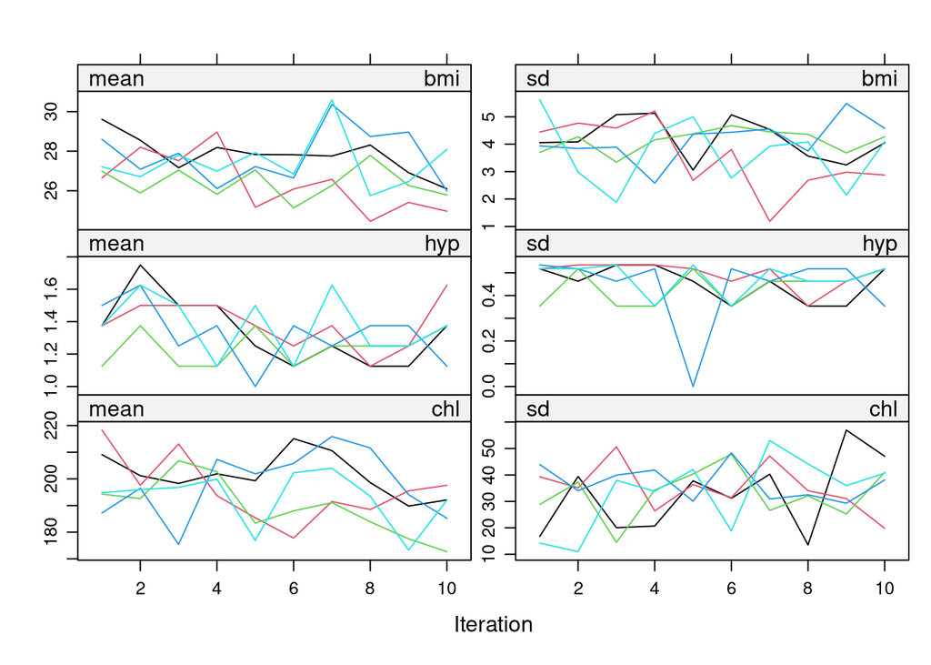

```r
plot(imp)
```

Notice that now the x-axis in the trace plots extends to 10 to reflect the higher number of iterations.

One common reason to increase the number of iterations is non-convergence. We’ll sometimes observe trends when we inspect the trace plots of the imputed items. These trends tell us that the algorithm has not yet reached an equilibrium point. In such situations, the first thing to try (so long as you don’t notice any obvious errors in your imputation model specification) is increasing the number of iterations. While we could accomplish this goal simply by rerunning `mice()` with a higher value for `maxit`, doing so would be very wasteful. We would have to recreate all of the existing iterations before generating any new iterations. Thankfully, we don’t need to be so inefficient.

We can easily extend the chains in any *mids* object with the `mice.mids()` function. This function takes as *mids* object as its primary argument and picks up the sampling where `mice()` left off (using exactly the same imputation model specification). The following code will extend the chains in our most recent *mids* object to 25 total iterations by adding on another 15 iterations.

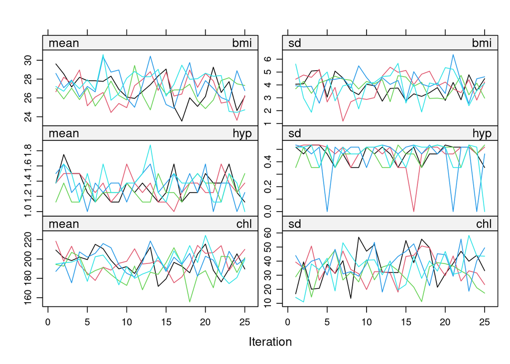

```r
imp <- mice.mids(imp, maxit = 15, print = FALSE)
plot(imp)
```

Now, `imp` contains 25 iterations, which we can see by the range of the x-axis in the trace plots.

## 8.1

**Increase the number of iterations for the imputation you ran in Question 7.2 to 25.**

# 9 More Diagnostics

Recall that even if the imputation model converges (e.g., as demonstrated by trace plots), the imputed values still might not be reasonable estimates of the missing data. If the data are MCAR, then the imputations should have the same distribution as the observed data. In general, though, the distributions of the observed and imputed data may differ when the data are MAR. However, we don’t want to see very large discrepancies.

Strip plots are another excellent visualization tool with which we can assess the comparability of the imputed and observed data. The `mice::stripplot()` function will generate strip plots from a *mids* object.

The following code will create a strip plot of the observed and imputed `chl` values.

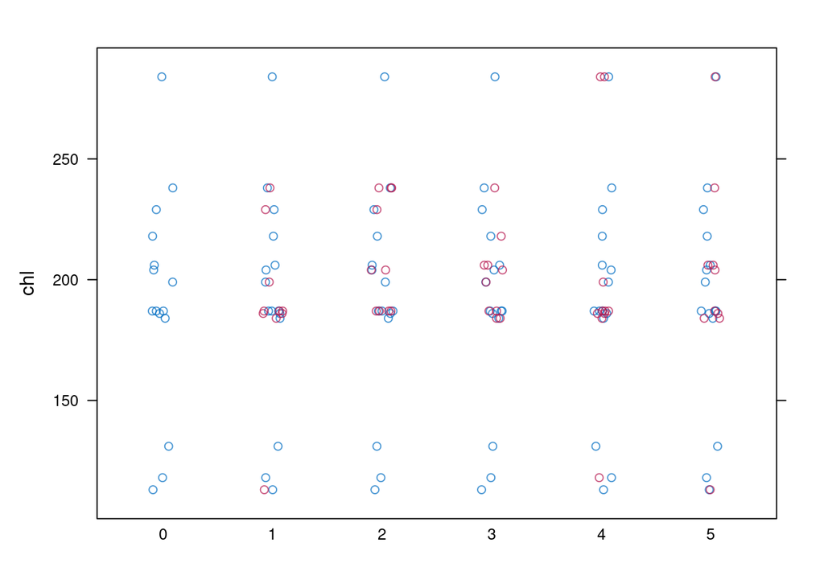

```r
stripplot(imp, chl)
```

The observed data are plotted in blue, and the imputed data are plotted in red. Since `chl` was imputed with PMM (which draws imputations from the observed data), the imputed values have the same gaps as the observed data, and the imputed values are always within the range of the observed data. This figure indicates that the observed and imputed values of `chl` follow similar distributions. So, we should conclude that these imputations are plausible.

We can also call `stripplot()` without specifying any variables. Doing so will plot all of the imputed variables in an array.

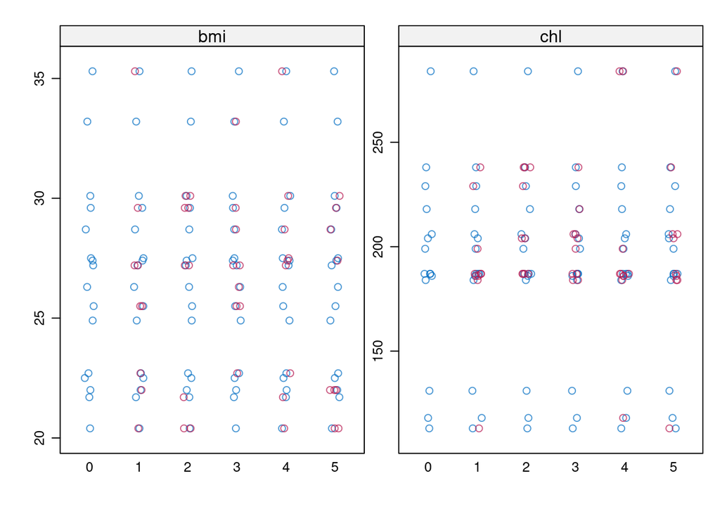

```r
stripplot(imp)
```

## 9.1

**Create trace plots, density plots, and strip plots for the *mids* object you created in Question 8.1.**

Based on these visualizations, would you say the imputation model has converged to a valid solution?

## 9.2

**Rerun the imputation from Question 8.1.**

Keep all the same settings, but use Bayesian linear regression to impute `bmi` and `chl`.

## 9.3

**Create trace plots, density plots, and strip plots for the *mids* object you created in Question 9.2.**

Based on the visualizations, are the imputations from Question 8.1 or Question 9.2 more reasonable? Why?

## 9.4

**Use the multiply imputed data you created in Question 8.1 to estimate the following regression model.**

$Y_{bmi} = \beta_0 + \beta_1 X_{age} = \beta_2 X_{chl} + \varepsilon$

## 9.5

**Pool the estimates from the model you estimated in Question 9.4.**

Is the effect of `chl` on `bmi` significant after controlling for `age`?

## 9.6

**Rerun the regression analysis from above using the imputed data from Question 9.2.**

Do the results differ between the two versions of the analysis? Why or why not?

End of Lab 2a